# Climate Change and Temperature Anomalies

Julia Tulloh

2020-09-20

If we wanted to study climate change, we can find data on the *Combined Land-Surface Air and Sea-Surface Water Temperature Anomalies* in the Northern Hemisphere at [NASA’s Goddard Institute for Space Studies](https://data.giss.nasa.gov/gistemp). The [tabular data of temperature anomalies can be found here](https://data.giss.nasa.gov/gistemp/tabledata_v3/NH.Ts+dSST.txt)

To define temperature anomalies you need to have a reference, or base, period which NASA clearly states that it is the period between 1951-1980.

First, we load the file.

```r
weather <-
  read_csv("https://data.giss.nasa.gov/gistemp/tabledata_v3/NH.Ts+dSST.csv",
           skip = 1,
           na = "***")
```

We select the year and twelve month variables from the ‘weather’ dataset and convert the data frame to a long format.

```r
#Selecting year and 12 month variables and converting to long format
tidyweather <- weather %>%
  select(c(Year,Jan,Feb,Mar,Apr,May,Jun,Jul,Aug,Sep,Oct,Nov,Dec))%>%
  pivot_longer(cols=2:13,names_to="Month",values_to="Delta")

glimpse(tidyweather)
```

```
## Rows: 1,680
## Columns: 3
## $ Year  <dbl> 1880, 1880, 1880, 1880, 1880, 1880, 1880, 1880, 1880, 1880, 188…
## $ Month <chr> "Jan", "Feb", "Mar", "Apr", "May", "Jun", "Jul", "Aug", "Sep", …
## $ Delta <dbl> -0.54, -0.38, -0.26, -0.37, -0.11, -0.22, -0.23, -0.24, -0.26, …
```

The data frame now has three variables: Year, Month, and Temperature Deviation.

Let us plot the data using a time-series scatter plot, and add a trendline. To do that, we first need to create a new variable called `date` in order to ensure that the `delta` values are plotted chronologically.

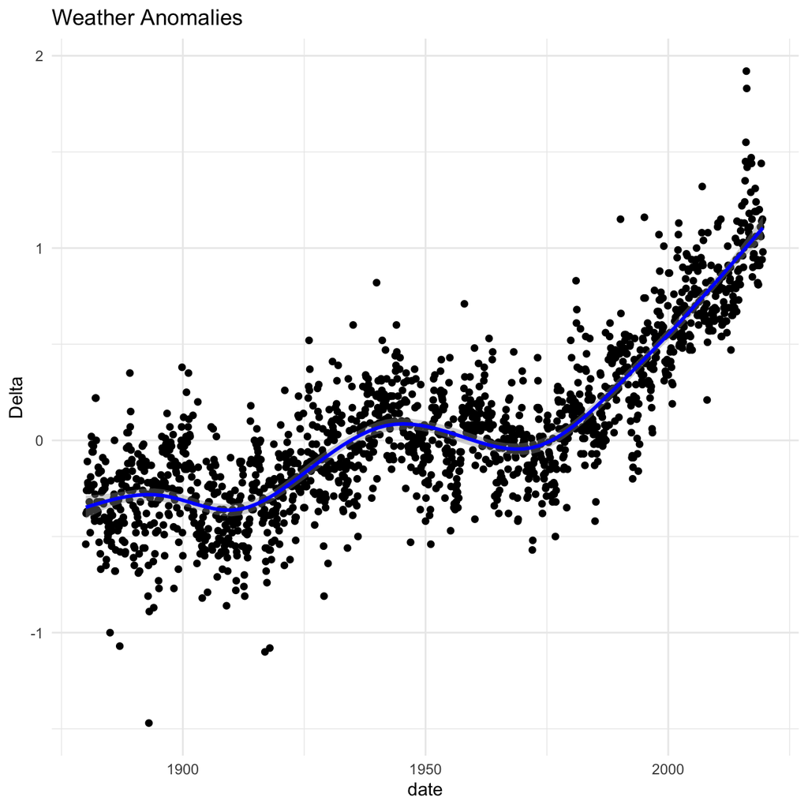

```r
tidyweather <- tidyweather %>%
  mutate(date = ymd(paste(as.character(Year), Month, "1")),
         month = month(date, label=TRUE),
         year = year(date))

ggplot(tidyweather, aes(x=date, y = Delta))+
  geom_point()+
  geom_smooth(color="blue") +
  theme_minimal() +
  labs (
    title = "Weather Anomalies"
  )
```

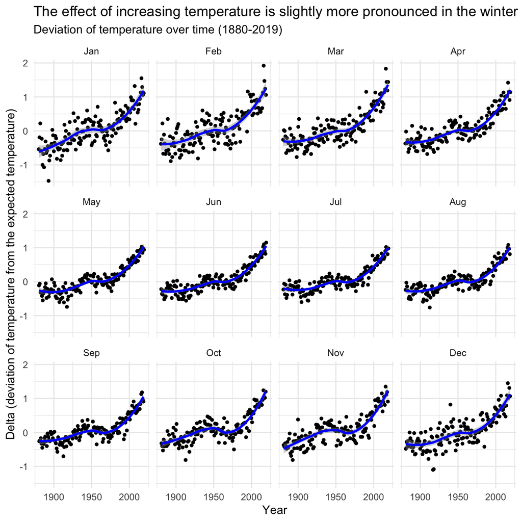

```r
#Creating a scatter plot by month

ggplot(tidyweather, aes(x=date, y = Delta))+
  geom_point(size = 1)+
  geom_smooth(color="blue") +
  theme_minimal() +
  facet_wrap(~month)+
  labs (title = "The effect of increasing temperature is slightly more pronounced in the winter", subtitle="Deviation of temperature over time (1880-2019)", y= "Delta (deviation of temperature from the expected temperature)", x="Year"
  )
```

It is sometimes useful to group data into different time periods to study historical data. For example, we often refer to decades such as 1970s, 1980s, 1990s etc. to refer to a period of time. NASA calcualtes a temperature anomaly, as difference form the base periof of 1951-1980. The code below creates a new data frame called `comparison` that groups data in five time periods: 1881-1920, 1921-1950, 1951-1980, 1981-2010 and 2011-present.

```r
comparison <- tidyweather %>%
  filter(Year>= 1881) %>%     #remove years prior to 1881
  #create new variable 'interval', and assign values based on criteria below:
  mutate(interval = case_when(
    Year %in% c(1881:1920) ~ "1881-1920",
    Year %in% c(1921:1950) ~ "1921-1950",
    Year %in% c(1951:1980) ~ "1951-1980",
    Year %in% c(1981:2010) ~ "1981-2010",
    TRUE ~ "2011-present"
  ))
```

Now that we have the `interval` variable, we can create a density plot to study the distribution of monthly deviations (`delta`), grouped by the different time periods we are interested in. Set `fill` to `interval` to group and color the data by different time periods.

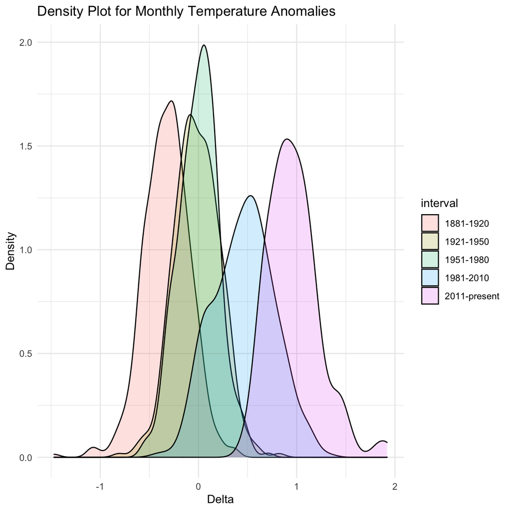

```r
ggplot(comparison, aes(x=Delta, fill=interval))+
  geom_density(alpha=0.2) +   #density plot with tranparency set to 20%
  theme_minimal() +                #theme
  labs (
    title = "Density Plot for Monthly Temperature Anomalies",
    y     = "Density"         #changing y-axis label to sentence case
  )
```

So far, we have been working with monthly anomalies, but now we will look at average annual anomalies. We can do this by using `group_by()` and `summarise()`, followed by a scatter plot to display the result.

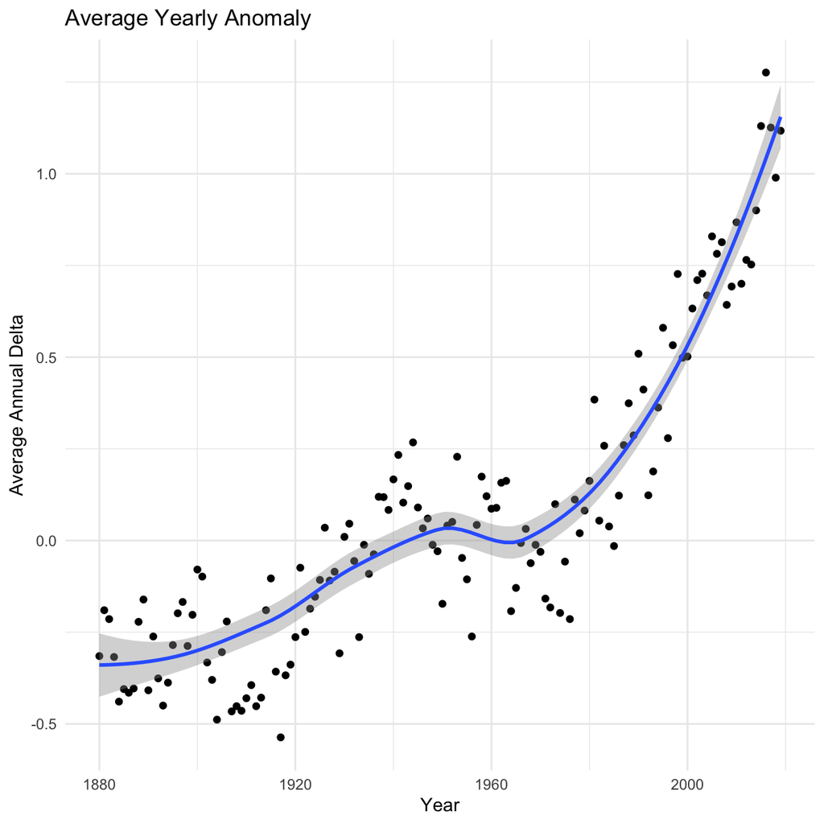

```r
#creating yearly averages
average_annual_anomaly <- tidyweather %>%
  group_by(Year) %>%   #grouping data by Year

  # creating summaries for mean delta
  # use `na.rm=TRUE` to eliminate NA (not available) values
  summarise(annual_average_delta = mean(Delta, na.rm=TRUE))

#plotting the data:
ggplot(average_annual_anomaly, aes(x=Year, y= annual_average_delta))+
  geom_point()+

  #Fit the best fit line, using LOESS method
  geom_smooth() +

  #change to theme_bw() to have white background + black frame around plot
  theme_minimal() +
  labs (
    title = "Average Yearly Anomaly",
    y     = "Average Annual Delta"
  )
```

Now, we will create a 95% confidence interval for delta (temperature deviation)

[NASA points out on their website](https://earthobservatory.nasa.gov/world-of-change/decadaltemp.php) that

> A one-degree global change is significant because it takes a vast amount of heat to warm all the oceans, atmosphere, and land by that much. In the past, a one- to two-degree drop was all it took to plunge the Earth into the Little Ice Age.

Below, we construct a 95% confidence interval for delta.

```r
formula_ci <- comparison %>%
  filter(interval=="2011-present")%>%
  summarize(
    median_delta =  median(Delta, na.rm=TRUE),
    mean_delta = mean(Delta, na.rm=TRUE),
    sd_delta = sd(Delta, na.rm=TRUE),
    count = n(),
    se_delta = sd_delta/ sqrt(count),
    t_critical = qt(0.975, count - 1 ),
    lower = mean_delta - t_critical * se_delta,
    upper = mean_delta + t_critical * se_delta
  )



#print out formula_CI
kable(formula_ci)%>%
  kable_styling()
```

| median_delta | mean_delta | sd_delta | count | se_delta | t_critical | lower | upper |
| --- | --- | --- | --- | --- | --- | --- | --- |
| 0.94 | 0.966 | 0.262 | 108 | 0.025 | 1.98 | 0.916 | 1.02 |

The 95% confidence interval for delta is 0.916-1.02.

Now, we will use the bootstrap method to create a confidence interval.

```r
set.seed(1234)

library(infer)

boot_delta <- comparison %>%
  filter(interval=="2011-present")%>%
  specify(response = Delta) %>%
  generate(reps = 1000, type = "bootstrap") %>%
  calculate(stat = "mean")

boot_ci <- boot_delta %>%
  get_ci(level = 0.95, type = "percentile")

kable(boot_ci)%>%
  kable_styling()
```

| lower_ci | upper_ci |
| --- | --- |
| 0.917 | 1.02 |

Here, we’ve created two confidence intervals, one using our dataset, and the other via bootstrapping for mean delta. The bootstrap method generated 1000 samples from our dataset with replacement, in order to approximate the distribution and estimate sample-to-sample variability. The bootstrap confidence interval shows us that we can be 95% confident that the true average delta between 2011-present lies between 0.917 and 1.02.